# Super Bowl Squares

crhenderson  
2015-09-26

[Github](https://github.com/crhenderson/Super-Bowl-Squares-App)

### What are Super Bowl Squares?

*Super Bowl Squares* is a betting game related to the NFL Super Bowl. Each square in the 10x10 grid represents a combination of the last digit of each teams score. Before the game starts, players buy squares and then the numbers 0:9 are randomly placed accross the top and side of the grid, ie, players blindly select squares.  
Example: The Cowboys just kicked a field goal and the score is now Cowboys 24 - Patriots 17. The last digits are 4 & 7 marked on the grid below. The owner of that square wins $.

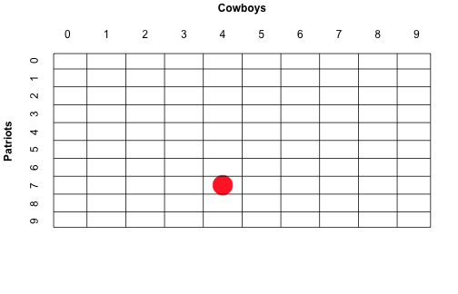

### Historic Data

One feature of this app is a breakdown of historical frequencies and empirical probabilities of different last digit combinations occuring. That way you can see what your chances of winning are if you drew the 3 & 5 square for example. The chart shows you how many games have had instances of 3 & 5.

```r
kable(historic.pergame(3,5))
```

| Combo | N | Games | Probability |
| --- | --- | --- | --- |
| 3 & 5 | 0 | 6465 | 97.7% |
| 3 & 5 | 1 | 147 | 2.2% |
| 3 & 5 | 2 | 6 | 0.1% |
| 3 & 5 | Total | 6618 | 100% |

### Historic Data

The **Historic Data** tab also shows the probability that each number combo will occur at least once in a game. 3 & 5 is marked in red.

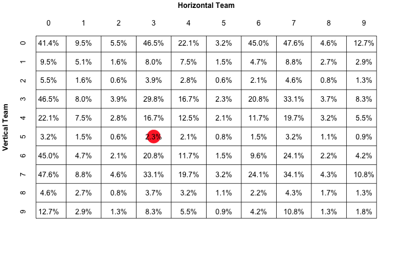

```r
p<-historic.table(3,5)
```

### Next Winning Square

```r
p<-probability.table(35, 28, 3, 1,"Cowboys","Patriots")
```

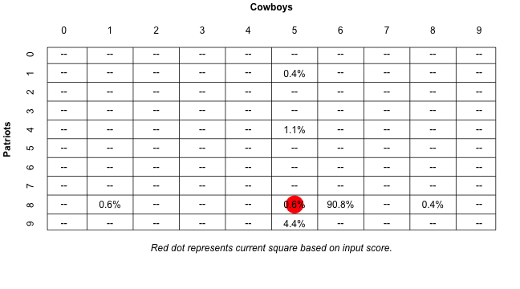